# Portfolio Backtesting

# Usage for grading students in a course

If an instructor wants to evaluate the students of a course in their portfolio design, it can also be done very easily. It suffices to ask each student to submit a .R script (necessary to be named uniquely like `STUDENTNUMBER-XXXX.R`) containing the portfolio function called exactly `portfolio_fun()` as well as any other auxiliary functions that it may require (needless to say that the required packages should be loaded in that script with `library()`). Then the instructor can put all those files in a folder and evaluate all of them at once.

```r
bt_all_students <- portfolioBacktest(folder_path = "folder_path", dataset =  dataset[1:3])
res_all_students <- backtestSummary(bt_all_students, summary_fun = median)
res_all_students$performance_summary
```

```
#>                      0001-GMVP 0002-Markowitz    0003-max
#> Sharpe ratio        0.55444212      1.0281566   1.0362853
#> max drawdown        0.10028747      0.2096863   0.1032808
#> annual return       0.05373523      0.2988824   0.1839548
#> annual volatility   0.09691766      0.2528989   0.1730935
#> Sterling ratio      0.53581199      1.5396412   1.7811132
#> Omega ratio         1.10578844      1.2101015   1.1976442
#> ROT bps           143.82195198    281.1637575 247.3082572
```

```r
res_all_students$cpu_time_average
```

[output not shown]

```r
res_all_students$failure_rate
```

```
#>      0001-GMVP 0002-Markowitz       0003-max
#>              0              0              0
```

Now we can rank the different portfolios/students based on a weighted combination of the rank percentiles (termed scores) of the performance measures:

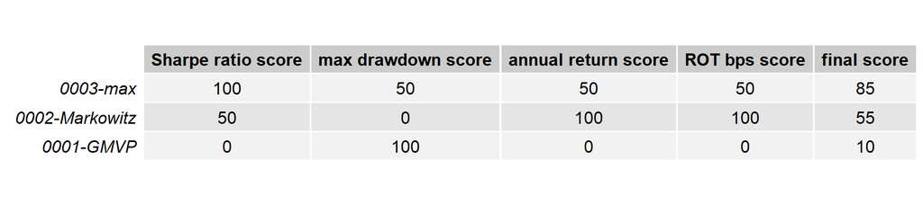

```r
leaderboard <- portfolioLeaderboard(bt_all_students, weights = list('Sharpe ratio' = 7, 'max drawdown' = 1,  'annual return' = 1, 'ROT bps' = 1))

# show leaderboard
library(gridExtra)
grid.table(leaderboard$leaderboard_scores)
```

## Example of a script file to be submitted by a student

Consider the student with id number 666. Then the script file should be named `666-XXX.R` and should contain the portfolio function called exactly `portfolio_fun()` as well as any other auxiliary functions that it may require (needless to say that the required packages should be loaded in that script with `library()`):

```r
library(CVXR)

auxiliary_function <- function(x) {
  # here whatever code
}

portfolio_fun <- function(prices) {
  X <- as.matrix(diff(log(data$adjusted))[-1])  # compute log returns
  mu <- colMeans(X)  # compute mean vector
  Sigma <- cov(X)  # compute the SCM
  # design mean-variance portfolio
  w <- Variable(nrow(Sigma))
  prob <- Problem(Maximize(t(mu) %*% w - 0.5*quad_form(w, Sigma)),
                  constraints = list(w >= 0, sum(w) == 1))
  result <- solve(prob)
  return(as.vector(result$getValue(w)))
}
```

# Appendix

## Performance criteria

The definition of performance criteria used in this package is listed as below

- **expetced return:** the [annualized return](https://www.investopedia.com/terms/a/annualized-total-return.asp)
- **volatility:** the [annualized standard deviation](https://www.fool.com/knowledge-center/how-to-calculate-annualized-volatility.aspx) of returns
- **max drawdown:** the maximum loss from a peak to a trough of a portfolio, see also [here](https://www.investopedia.com/terms/m/maximum-drawdown-mdd.asp)
- **Sharpe ratio:** [annualized Sharpe ratio](https://en.wikipedia.org/wiki/Sharpe_ratio), the ratio between `annualized return` and `annualized standard deviation`
- **Sterling ratio:** the return over average drawdown, see [here](https://en.m.wikipedia.org/wiki/Sterling_ratio) for complete definition. In the package, we use
  $$\text{Sterling ratio} = \frac{\text{annualized return}}{\text{max drawdown}}$$
- **Omega ratio:** the probability weighted ratio of gains over losses for some threshold return target, see [here](https://en.m.wikipedia.org/wiki/Omega_ratio) for complete definition. The ratio is calculated as:
  $$\Omega(r) = \frac{\int_{r}^{\infty} (1-F(x))dx}{\int_{-\infty}^{r} F(x)dx}$$
  In the package, we use $\Omega(0)$, which is also known as Gain-Loss-Ratio.
- **Return over Turnover (ROT):** the sum of cummulative return over the sum of turnover.